# 4_Linear_Regression

MariaGladkaya

2023-12-19

```r
knitr::opts_chunk$set(echo = TRUE)
```

## Считываем дата-сет

```r
library(readxl)
df <- read_excel("~/spbu_studies/mat_statistics/MatStat4-6/datasets/kuiper.xls")
View(df)
```

## Корреляционный анализ

### g. Построить график рассеяния и уравнения регрессии.

- Под глав. диагональю: графики рассеивания. Попарная зависимость
- Глав. диагон.: гистограммы. Эмпирич. аналог плотности распределения
- Над глав. диагон.: выборочные коэф-ты корреляции (критерий Пирсона) Н0: Коэф-т кор. = 0 (кор. отсутствует)

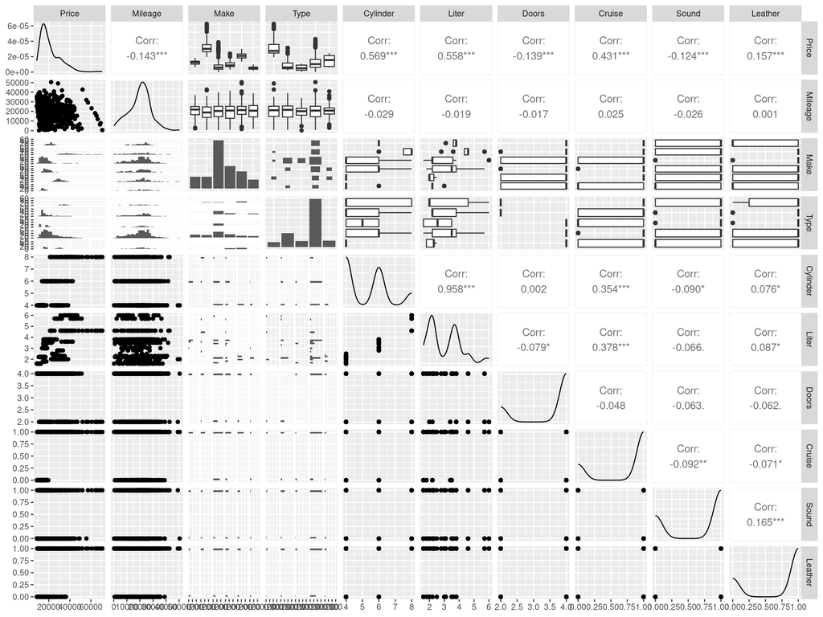

```r
library(GGally)
library(ggplot2)
ggpairs(df)
```

### a.Провести корреляционный анализ имеющихся данных.  
#### Матрица корреляции Пирсона

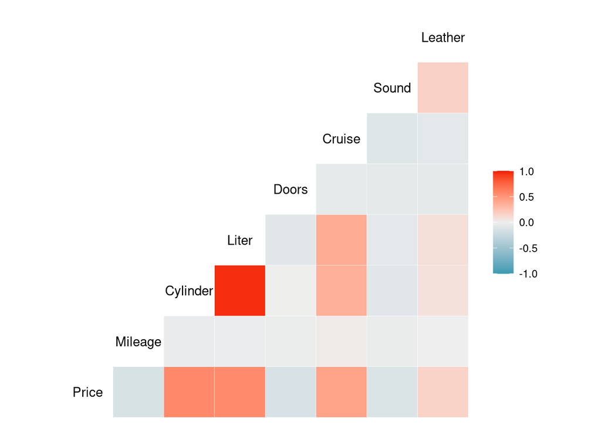

```r
ggcorr(df, method = c("everything", "pearson"))
```

#### Проверить значимость можно так же попарно

```r
cor.test(df$Price, df$Mileage)
```

```
##
##  Pearson's product-moment correlation
##
## data:  df$Price and df$Mileage
## t = -4.0932, df = 802, p-value = 4.685e-05
## alternative hypothesis: true correlation is not equal to 0
## 95 percent confidence interval:
##  -0.21011376 -0.07464739
## sample estimates:
##        cor
## -0.1430505
```

## Ур. линейной регрессии и Постороение регрессионной модели

### b. Построить базовую модель линейной регрессии.

### c. Вывести результаты анализа базовой модели.

### d. Записать уравнение линейной регрессии.

### e. Проверить значимость каждого отдельного коэффициента с помощью T-test.

### f. Проверить значимость построенного уравнения регрессии с помощью F-test.

```r
m1 <- lm(Price~Mileage+Make+Type+Cylinder+Liter+Doors+Cruise+Sound+Leather, df)
summary(m1)
```

```
##
## Call:
## lm(formula = Price ~ Mileage + Make + Type + Cylinder + Liter +
##     Doors + Cruise + Sound + Leather, data = df)
##
## Residuals:
##     Min      1Q  Median      3Q     Max
## -8224.9 -1416.2   -12.2  1153.9 14878.2
##
## Coefficients: (1 not defined because of singularities)
##                 Estimate Std. Error t value Pr(>|t|)
## (Intercept)    2.279e+04  1.000e+03  22.790  < 2e-16 ***
## Mileage       -1.849e-01  1.088e-02 -16.994  < 2e-16 ***
## MakeCadillac   1.586e+04  4.890e+02  32.436  < 2e-16 ***
## MakeChevrolet -1.748e+03  3.602e+02  -4.853 1.47e-06 ***
## MakePontiac   -1.893e+03  3.680e+02  -5.145 3.38e-07 ***
## MakeSAAB       1.054e+04  4.580e+02  23.008  < 2e-16 ***
## MakeSaturn    -1.236e+03  4.788e+02  -2.582 0.010010 *
## TypeCoupe     -1.202e+04  4.733e+02 -25.402  < 2e-16 ***
## TypeHatchback -1.238e+04  5.524e+02 -22.413  < 2e-16 ***
## TypeSedan     -1.235e+04  4.105e+02 -30.091  < 2e-16 ***
## TypeWagon     -8.284e+03  5.135e+02 -16.134  < 2e-16 ***
## Cylinder      -1.226e+03  3.162e+02  -3.877 0.000114 ***
## Liter          5.761e+03  3.545e+02  16.252  < 2e-16 ***
## Doors                 NA         NA      NA       NA
## Cruise         1.111e+02  2.567e+02   0.433 0.665131
## Sound          2.956e+02  2.033e+02   1.454 0.146222
## Leather        2.343e+02  2.190e+02   1.070 0.285023
## ---
## Signif. codes:  0 '***' 0.001 '**' 0.01 '*' 0.05 '.' 0.1 ' ' 1
##
## Residual standard error: 2517 on 788 degrees of freedom
## Multiple R-squared:  0.9364, Adjusted R-squared:  0.9352
## F-statistic: 773.3 on 15 and 788 DF,  p-value: < 2.2e-16
```

#### Трактовка:

Выводится *ур. модели линейной регрессии*

*Residuals* - остатки. Разность между наблюдаемым значением и предсказанным. И для них посчитаны квантили

*Coefficients:*

- Estimate - оценки коэф-тов в ур-нии
- Std. Error, t value - стандартная ошибка и значение статистики Т
- Статистика Стьюдента Н0: коэф-т равен 0 (не значим) принимаем => не значим отвергаем => значим (р < 0.05)

*Multiple R-squared:* чем ближе к 1, тем лучше (разброс данных как можно лучше объясняется с пом. построенного ур. лин. регрессии)

**Отвергаем** Н0: ур. лин. регресси не значимо в целом (Все коэф-ты одновременно = 0) => **ур. лин. регресси значимо**

### h. Построить доверительные интервалы для коэффициентов регрессии.

```r
confint(m1)
```

```
##                       2.5 %        97.5 %
## (Intercept)    2.082827e+04  2.475453e+04
## Mileage       -2.062162e-01 -1.635087e-01
## MakeCadillac   1.490014e+04  1.681975e+04
## MakeChevrolet -2.455384e+03 -1.041132e+03
## MakePontiac   -2.615334e+03 -1.170763e+03
## MakeSAAB       9.638640e+03  1.143671e+04
## MakeSaturn    -2.176048e+03 -2.962678e+02
## TypeCoupe     -1.295197e+04 -1.109383e+04
## TypeHatchback -1.346644e+04 -1.129755e+04
## TypeSedan     -1.315900e+04 -1.154731e+04
## TypeWagon     -9.292431e+03 -7.276496e+03
## Cylinder      -1.846875e+03 -6.053403e+02
## Liter          5.065333e+03  6.457083e+03
## Doors                    NA            NA
## Cruise        -3.927229e+02  6.150142e+02
## Sound         -1.033623e+02  6.946073e+02
## Leather       -1.955711e+02  6.640883e+02
```

С вероятностью 95% значения переменных попадают в этот интервал

#### Анализ значимости регресионной модели, построенной только на одной переменной для всех переменных.

```r
anova(m1)
```

```
## Analysis of Variance Table
##
## Response: Price
##            Df     Sum Sq    Mean Sq   F value Pr(>F)
## Mileage     1 1.6056e+09 1.6056e+09  253.4970 <2e-16 ***
## Make        5 5.0544e+10 1.0109e+10 1596.0235 <2e-16 ***
## Type        4 9.1459e+09 2.2865e+09  360.9986 <2e-16 ***
## Cylinder    1 1.0364e+10 1.0364e+10 1636.3279 <2e-16 ***
## Liter       1 1.7862e+09 1.7862e+09  282.0142 <2e-16 ***
## Cruise      1 4.9503e+05 4.9503e+05    0.0782 0.7799
## Sound       1 1.6594e+07 1.6594e+07    2.6200 0.1059
## Leather     1 7.2492e+06 7.2492e+06    1.1445 0.2850
## Residuals 788 4.9910e+09 6.3338e+06
## ---
## Signif. codes:  0 '***' 0.001 '**' 0.01 '*' 0.05 '.' 0.1 ' ' 1
```

### j. Используя функцию Step или StepAIC, постараться улучшить модель.

*Start: AIC=12607.61* - рассмотрим все переменные как объясняющие

Для модели смотрим по переменным, как изменится AIC при удалении(-) или прибавлении(+) той или иной переменной

```r
step(m1, direction = "both")
```

```
## Start:  AIC=12607.61
## Price ~ Mileage + Make + Type + Cylinder + Liter + Doors + Cruise +
##     Sound + Leather
##
##
## Step:  AIC=12607.61
## Price ~ Mileage + Make + Type + Cylinder + Liter + Cruise + Sound +
##     Leather
##
##            Df  Sum of Sq        RSS   AIC
## - Cruise    1 1.1875e+06 4.9922e+09 12606
## - Leather   1 7.2492e+06 4.9983e+09 12607
## <none>                   4.9910e+09 12608
## - Sound     1 1.3398e+07 5.0044e+09 12608
## - Cylinder  1 9.5212e+07 5.0862e+09 12621
## - Liter     1 1.6729e+09 6.6639e+09 12838
## - Mileage   1 1.8291e+09 6.8201e+09 12857
## - Type      4 5.9554e+09 1.0946e+10 13231
## - Make      5 1.9638e+10 2.4629e+10 13881
##
## Step:  AIC=12605.8
## Price ~ Mileage + Make + Type + Cylinder + Liter + Sound + Leather
##
##            Df  Sum of Sq        RSS   AIC
## - Leather   1 6.7490e+06 4.9989e+09 12605
## <none>                   4.9922e+09 12606
## - Sound     1 1.3269e+07 5.0055e+09 12606
## + Cruise    1 1.1875e+06 4.9910e+09 12608
## - Cylinder  1 9.4313e+07 5.0865e+09 12619
## - Liter     1 1.6829e+09 6.6751e+09 12837
## - Mileage   1 1.8282e+09 6.8204e+09 12855
## - Type      4 5.9595e+09 1.0952e+10 13229
## - Make      5 2.1471e+10 2.6463e+10 13937
##
## Step:  AIC=12604.89
## Price ~ Mileage + Make + Type + Cylinder + Liter + Sound
##
##            Df  Sum of Sq        RSS   AIC
## <none>                   4.9989e+09 12605
## - Sound     1 1.6402e+07 5.0153e+09 12606
## + Leather   1 6.7490e+06 4.9922e+09 12606
## + Cruise    1 6.8732e+05 4.9983e+09 12607
## - Cylinder  1 1.0311e+08 5.1021e+09 12619
## - Liter     1 1.7560e+09 6.7549e+09 12845
## - Mileage   1 1.8248e+09 6.8237e+09 12853
## - Type      4 5.9531e+09 1.0952e+10 13228
## - Make      5 2.2789e+10 2.7788e+10 13974
```

```
##
## Call:
## lm(formula = Price ~ Mileage + Make + Type + Cylinder + Liter +
##     Sound, data = df)
##
## Coefficients:
##   (Intercept)        Mileage   MakeCadillac  MakeChevrolet    MakePontiac
##     2.295e+04     -1.846e-01      1.601e+04     -1.703e+03     -1.866e+03
##      MakeSAAB     MakeSaturn      TypeCoupe  TypeHatchback      TypeSedan
##     1.064e+04     -1.261e+03     -1.199e+04     -1.235e+04     -1.234e+04
##     TypeWagon       Cylinder          Liter          Sound
##    -8.266e+03     -1.262e+03      5.825e+03      3.238e+02
```

В итоге выводится модель, дающая наименьший AIC

```r
library(MASS)
stepAIC(m1)
```

```
## Start:  AIC=12607.61
## Price ~ Mileage + Make + Type + Cylinder + Liter + Doors + Cruise +
##     Sound + Leather
##
##
## Step:  AIC=12607.61
## Price ~ Mileage + Make + Type + Cylinder + Liter + Cruise + Sound +
##     Leather
##
##            Df  Sum of Sq        RSS   AIC
## - Cruise    1 1.1875e+06 4.9922e+09 12606
## - Leather   1 7.2492e+06 4.9983e+09 12607
## <none>                   4.9910e+09 12608
## - Sound     1 1.3398e+07 5.0044e+09 12608
## - Cylinder  1 9.5212e+07 5.0862e+09 12621
## - Liter     1 1.6729e+09 6.6639e+09 12838
## - Mileage   1 1.8291e+09 6.8201e+09 12857
## - Type      4 5.9554e+09 1.0946e+10 13231
## - Make      5 1.9638e+10 2.4629e+10 13881
##
## Step:  AIC=12605.8
## Price ~ Mileage + Make + Type + Cylinder + Liter + Sound + Leather
##
##            Df  Sum of Sq        RSS   AIC
## - Leather   1 6.7490e+06 4.9989e+09 12605
## <none>                   4.9922e+09 12606
## - Sound     1 1.3269e+07 5.0055e+09 12606
## - Cylinder  1 9.4313e+07 5.0865e+09 12619
## - Liter     1 1.6829e+09 6.6751e+09 12837
## - Mileage   1 1.8282e+09 6.8204e+09 12855
## - Type      4 5.9595e+09 1.0952e+10 13229
## - Make      5 2.1471e+10 2.6463e+10 13937
##
## Step:  AIC=12604.89
## Price ~ Mileage + Make + Type + Cylinder + Liter + Sound
##
##            Df  Sum of Sq        RSS   AIC
## <none>                   4.9989e+09 12605
## - Sound     1 1.6402e+07 5.0153e+09 12606
## - Cylinder  1 1.0311e+08 5.1021e+09 12619
## - Liter     1 1.7560e+09 6.7549e+09 12845
## - Mileage   1 1.8248e+09 6.8237e+09 12853
## - Type      4 5.9531e+09 1.0952e+10 13228
## - Make      5 2.2789e+10 2.7788e+10 13974
```

```
##
## Call:
## lm(formula = Price ~ Mileage + Make + Type + Cylinder + Liter +
##     Sound, data = df)
##
## Coefficients:
##   (Intercept)        Mileage   MakeCadillac  MakeChevrolet    MakePontiac
##     2.295e+04     -1.846e-01      1.601e+04     -1.703e+03     -1.866e+03
##      MakeSAAB     MakeSaturn      TypeCoupe  TypeHatchback      TypeSedan
##     1.064e+04     -1.261e+03     -1.199e+04     -1.235e+04     -1.234e+04
##     TypeWagon       Cylinder          Liter          Sound
##    -8.266e+03     -1.262e+03      5.825e+03      3.238e+02
```

### k. В случае получения в предыдущем пункте модели, отличной от базовой, повторить пп. c-i для новой модели.

```r
m2 <- lm(formula = Price ~ Mileage + Make + Type + Cylinder + Liter +
    Sound, data = df)
summary(m2)
```

```
##
## Call:
## lm(formula = Price ~ Mileage + Make + Type + Cylinder + Liter +
##     Sound, data = df)
##
## Residuals:
##     Min      1Q  Median      3Q     Max
## -8236.5 -1378.4    -6.2  1163.5 14890.5
##
## Coefficients:
##                 Estimate Std. Error t value Pr(>|t|)
## (Intercept)    2.295e+04  9.899e+02  23.181  < 2e-16 ***
## Mileage       -1.846e-01  1.087e-02 -16.982  < 2e-16 ***
## MakeCadillac   1.601e+04  4.636e+02  34.524  < 2e-16 ***
## MakeChevrolet -1.703e+03  3.498e+02  -4.868 1.36e-06 ***
## MakePontiac   -1.866e+03  3.629e+02  -5.142 3.43e-07 ***
## MakeSAAB       1.064e+04  4.457e+02  23.867  < 2e-16 ***
## MakeSaturn    -1.261e+03  4.698e+02  -2.685   0.0074 **
## TypeCoupe     -1.199e+04  4.716e+02 -25.420  < 2e-16 ***
## TypeHatchback -1.235e+04  5.476e+02 -22.552  < 2e-16 ***
## TypeSedan     -1.234e+04  4.099e+02 -30.093  < 2e-16 ***
## TypeWagon     -8.266e+03  5.122e+02 -16.137  < 2e-16 ***
## Cylinder      -1.262e+03  3.127e+02  -4.037 5.95e-05 ***
## Liter          5.825e+03  3.497e+02  16.658  < 2e-16 ***
## Sound          3.238e+02  2.011e+02   1.610   0.1078
## ---
## Signif. codes:  0 '***' 0.001 '**' 0.01 '*' 0.05 '.' 0.1 ' ' 1
##
## Residual standard error: 2516 on 790 degrees of freedom
## Multiple R-squared:  0.9363, Adjusted R-squared:  0.9352
## F-statistic:   893 on 13 and 790 DF,  p-value: < 2.2e-16
```

*Multiple R-squared:* уменьшился

## Диагностика модели линейной регрессии

### l. Построить графики: scatterplot, “Residuals vs Fitted”, “Normal Q-Q” , “Residuals vs Leverage” и дать интерпретации.

*Residuals vs Fitted* - x - оценки, полученные с пом модели лин регр

```
                    у - остатки(точки)
```

*Normal Q-Q* - анализ совместного распр. случайных величин (сопоставляются теор. и эмпир. квантили)

[output not shown]

*Residuals vs Leverage* - оценить имеются ли важные значения в выборке (которые существенно изменят модель). Они заходят за Cook’s distance

*Scale-Location* - выявить влиятельные значения

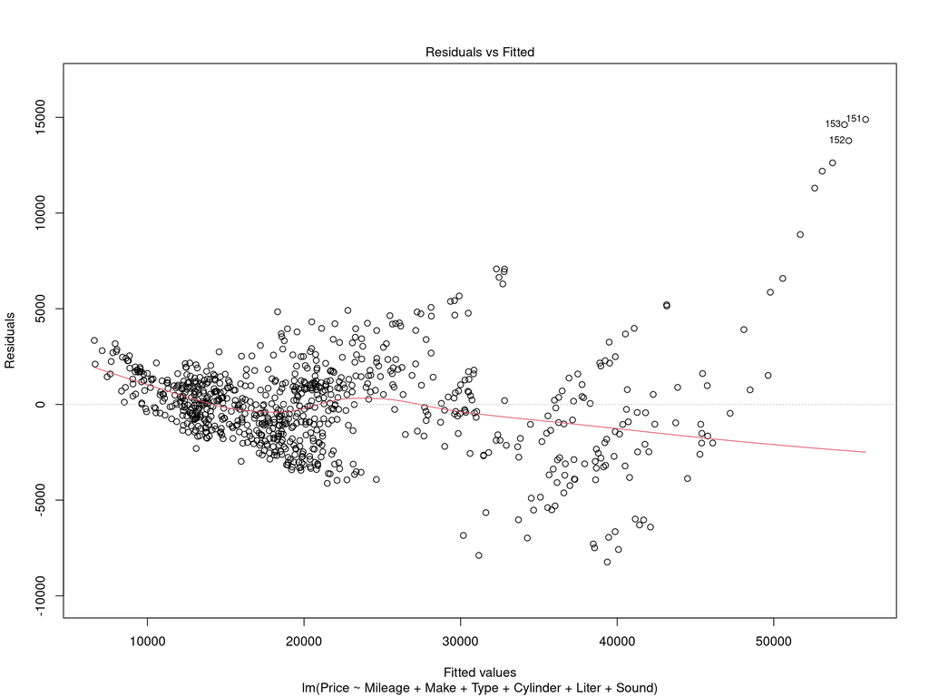

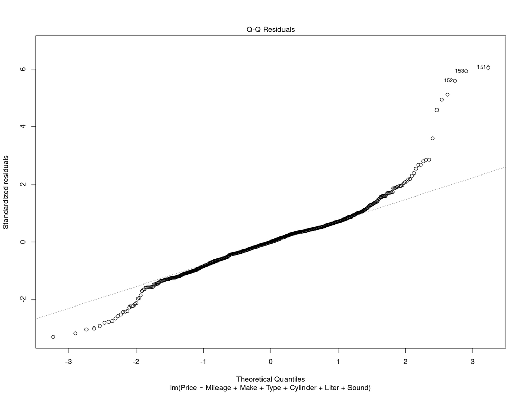

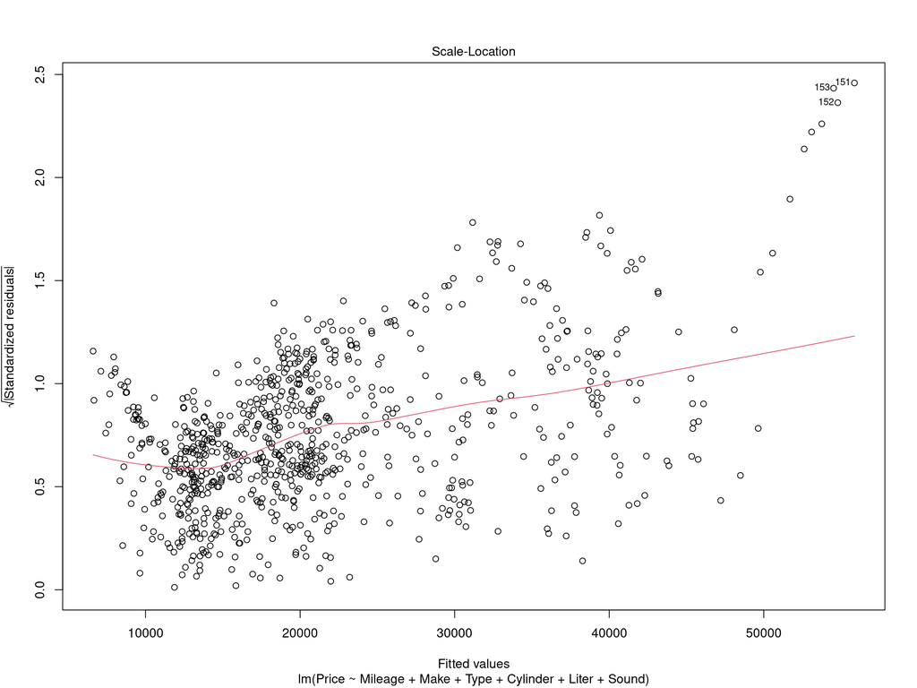

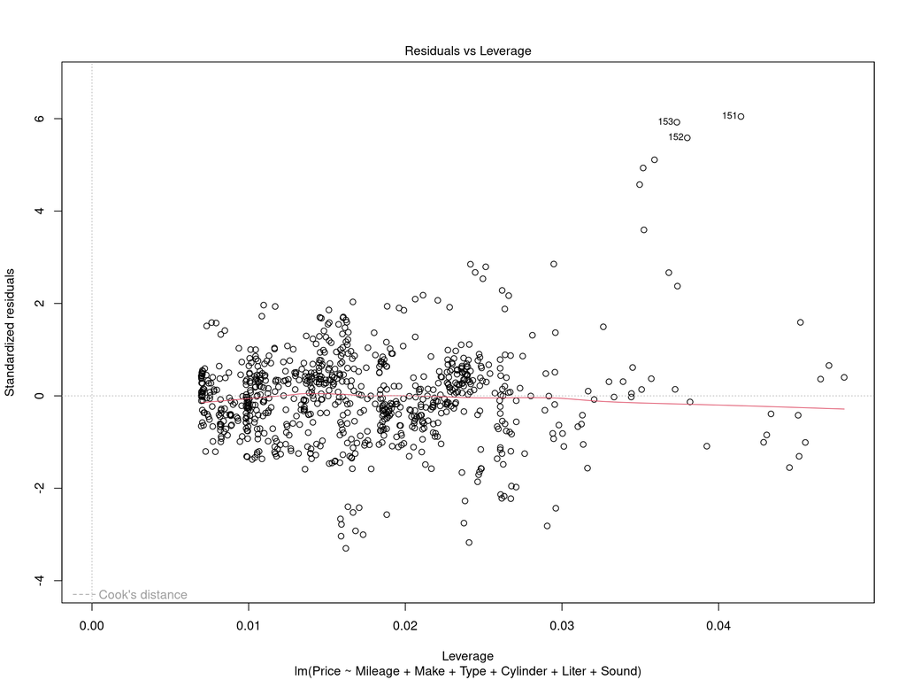

```r
plot(m2)
```

### m. Проверить модель на наличие выбросов.

```r
library(car)
outlierTest(m2, n.max=5)
```

```
##     rstudent unadjusted p-value Bonferroni p
## 151 6.187030         9.8410e-10   7.9122e-07
## 153 6.054946         2.1714e-09   1.7458e-06
## 152 5.694621         1.7445e-08   1.4026e-05
## 154 5.193029         2.6351e-07   2.1187e-04
## 155 5.007510         6.8058e-07   5.4719e-04
```

### n. Проверить модель на гетероскедастичность.

H0: дисперсии остатков одинаковы (гомоскедастичность) - нет проблемы H1: дисперсии остатков различны (гетероскедастичность)

```r
ncvTest(m2)
```

```
## Non-constant Variance Score Test
## Variance formula: ~ fitted.values
## Chisquare = 718.138, Df = 1, p = < 2.22e-16
```

Отвергаем Н0 => гетероскедастичность

```r
library(lmtest)
bptest(m2)
```

```
##
##  studentized Breusch-Pagan test
##
## data:  m2
## BP = 244.48, df = 13, p-value < 2.2e-16
```

### o. Проверить остатки модели на автокорреляцию.

Проверяет зависимость или независимость остатков

```r
durbinWatsonTest(m2)
```

```
##  lag Autocorrelation D-W Statistic p-value
##    1       0.8363635     0.3257658       0
##  Alternative hypothesis: rho != 0
```

H0: p=0 (нет автокорреляции) р != 0 => есть автокорреляция

```r
dwtest(m2)
```

```
##
##  Durbin-Watson test
##
## data:  m2
## DW = 0.32577, p-value < 2.2e-16
## alternative hypothesis: true autocorrelation is greater than 0
```

```r
dwtest(m2, alternative = "two.sided")
```

```
##
##  Durbin-Watson test
##
## data:  m2
## DW = 0.32577, p-value < 2.2e-16
## alternative hypothesis: true autocorrelation is not 0
```

### p. Проверить остатки модели на нормальность распределения.

Везде отвергаем ноормальность

```r
library(olsrr)
ols_test_normality(m2)
```

```
## -----------------------------------------------
##        Test             Statistic       pvalue
## -----------------------------------------------
## Shapiro-Wilk              0.9222         0.0000
## Kolmogorov-Smirnov        0.0851         0.0000
## Cramer-von Mises         66.7832         0.0000
## Anderson-Darling          9.5417         0.0000
## -----------------------------------------------
```

Остатки должны быть равномерно разбросаны относительно прямой у = 0

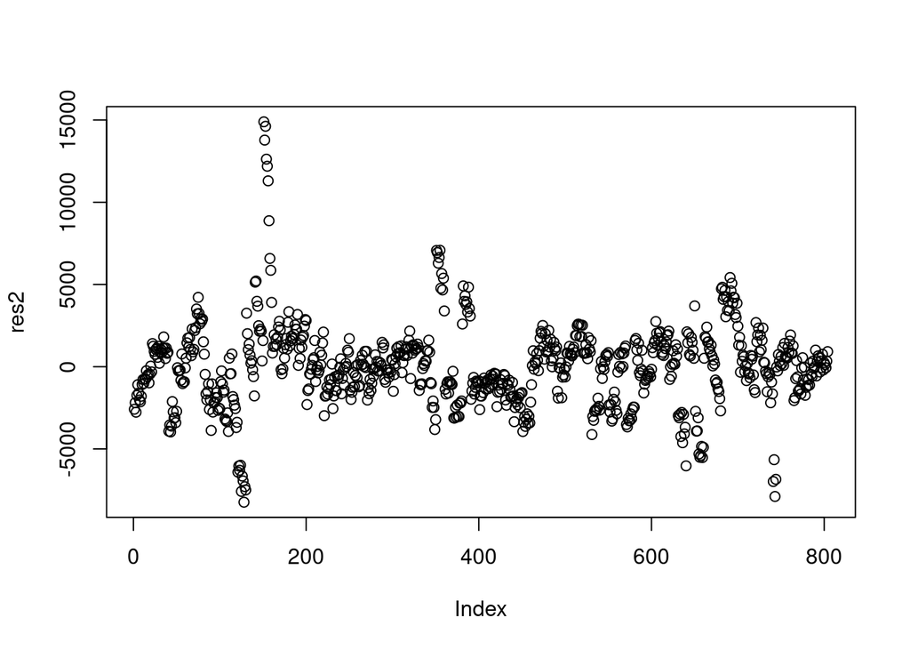

```r
library(nortest)
res2 <- residuals(m2)
plot(res2)
```

Не норм распр

```r
lillie.test(res2)
```

```
##
##  Lilliefors (Kolmogorov-Smirnov) normality test
##
## data:  res2
## D = 0.085055, p-value = 4.456e-15
```

```r
pearson.test(res2)
```

```
##
##  Pearson chi-square normality test
##
## data:  res2
## P = 103.69, p-value = 6.336e-11
```

Харке-Бера проверяет нормальность по моментам

```r
library(tseries)
jarque.bera.test(res2)
```

```
##
##  Jarque Bera Test
##
## data:  res2
## X-squared = 1371.2, df = 2, p-value < 2.2e-16
```

```r
ad.test(res2)
```

```
##
##  Anderson-Darling normality test
##
## data:  res2
## A = 9.5417, p-value < 2.2e-16
```

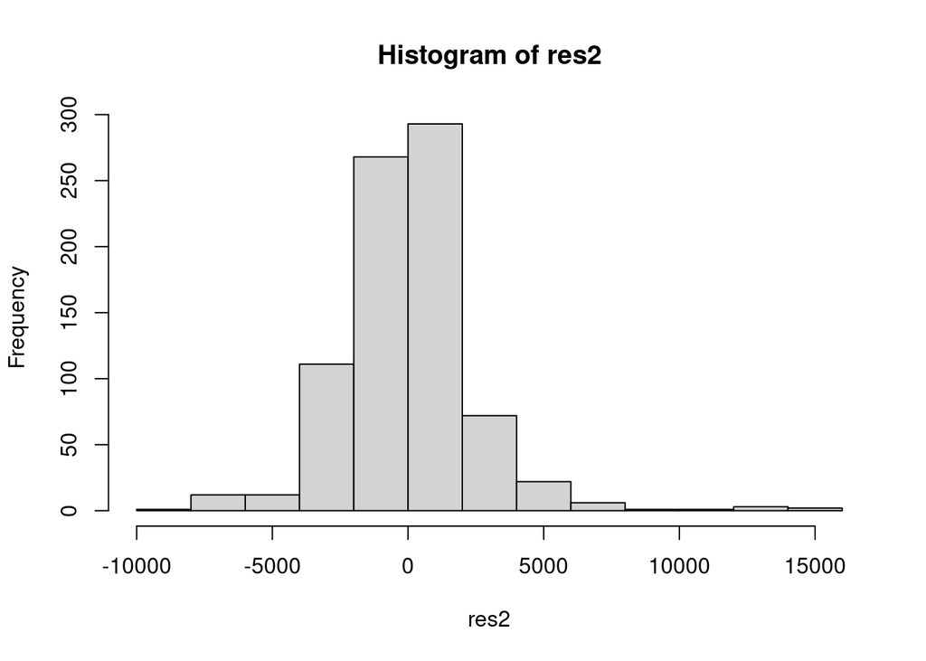

```r
hist(res2)
```

### q. Проверить модель на мультиколлинеарность данных.

Мультиколлинеарность - линейная зависимость одной независимой переменной от линейной комбинации других переменных

**Проблема мультиколлинеарности не возникает, когда все коэф-ты < 10**

```r
ols_vif_tol(m2)
```

```
##        Variables  Tolerance       VIF
## 1        Mileage 0.99270586  1.007348
## 2   MakeCadillac 0.40867484  2.446933
## 3  MakeChevrolet 0.26844748  3.725123
## 4    MakePontiac 0.39382137  2.539222
## 5       MakeSAAB 0.32561496  3.071112
## 6     MakeSaturn 0.51641239  1.936437
## 7      TypeCoupe 0.24607502  4.063801
## 8  TypeHatchback 0.38003364  2.631346
## 9      TypeSedan 0.19679311  5.081479
## 10     TypeWagon 0.40940628  2.442561
## 11      Cylinder 0.04186015 23.889066
## 12         Liter 0.05272456 18.966493
## 13         Sound 0.89307864  1.119722
```

```r
library(car)
vif(m2)
```

```
##               GVIF Df GVIF^(1/(2*Df))
## Mileage   1.007348  1        1.003667
## Make      5.026068  5        1.175230
## Type      2.557707  4        1.124557
## Cylinder 23.889066  1        4.887644
## Liter    18.966493  1        4.355054
## Sound     1.119722  1        1.058169
```

### r. Попробовать применить трансформацию Box-Cox зависимой переменной.

Улучшение модели с пом. степенного преобразования зависимой переменной у

```r
library(MASS)
bc <- boxCox(m2)
```

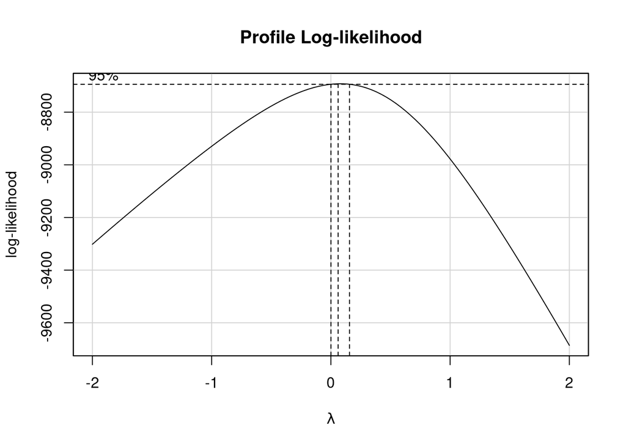

вертикальные линии показывают точечные значения в которых достигается макс. знач. функции правдоподобия. + доверительный интервал

```r
which.max(bc$y)
```

```
## [1] 52
```

```r
lambda <- bc$x[which.max(bc$y)]
lambda
```

```
## [1] 0.06060606
```

```r
z <- df$Price^lambda
df2 <- df[, -1]
df2$Price <- z
df2
```

```
## # A tibble: 804 × 10
##    Mileage Make  Type  Cylinder Liter Doors Cruise Sound Leather Price
##      <dbl> <chr> <chr>    <dbl> <dbl> <dbl>  <dbl> <dbl>   <dbl> <dbl>
##  1    8221 Buick Sedan        6   3.1     4      1     1       1  1.81
##  2    9135 Buick Sedan        6   3.1     4      1     1       0  1.81
##  3   13196 Buick Sedan        6   3.1     4      1     1       0  1.80
##  4   16342 Buick Sedan        6   3.1     4      1     0       0  1.80
##  5   19832 Buick Sedan        6   3.1     4      1     0       1  1.80
##  6   22236 Buick Sedan        6   3.1     4      1     1       0  1.80
##  7   22576 Buick Sedan        6   3.1     4      1     1       0  1.79
##  8   22964 Buick Sedan        6   3.1     4      1     1       0  1.79
##  9   24021 Buick Sedan        6   3.1     4      1     0       1  1.79
## 10   27325 Buick Sedan        6   3.1     4      1     1       1  1.79
## # ℹ 794 more rows
```

```r
m3 <- lm(formula = Price ~., data = df2)
summary(m3)
```

```
##
## Call:
## lm(formula = Price ~ ., data = df2)
##
## Residuals:
##       Min        1Q    Median        3Q       Max
## -0.037122 -0.006552  0.000635  0.006652  0.031215
##
## Coefficients: (1 not defined because of singularities)
##                 Estimate Std. Error t value Pr(>|t|)
## (Intercept)    1.797e+00  3.951e-03 454.734  < 2e-16 ***
## Mileage       -9.107e-07  4.298e-08 -21.187  < 2e-16 ***
## MakeCadillac   5.280e-02  1.932e-03  27.331  < 2e-16 ***
## MakeChevrolet -1.403e-02  1.423e-03  -9.859  < 2e-16 ***
## MakePontiac   -1.044e-02  1.454e-03  -7.180 1.61e-12 ***
## MakeSAAB       5.974e-02  1.810e-03  33.011  < 2e-16 ***
## MakeSaturn    -1.091e-02  1.892e-03  -5.768 1.15e-08 ***
## TypeCoupe     -3.708e-02  1.870e-03 -19.831  < 2e-16 ***
## TypeHatchback -4.079e-02  2.183e-03 -18.689  < 2e-16 ***
## TypeSedan     -3.764e-02  1.622e-03 -23.205  < 2e-16 ***
## TypeWagon     -1.985e-02  2.029e-03  -9.784  < 2e-16 ***
## Cylinder      -3.309e-03  1.249e-03  -2.648  0.00826 **
## Liter          2.781e-02  1.401e-03  19.856  < 2e-16 ***
## Doors                 NA         NA      NA       NA
## Cruise         1.978e-03  1.014e-03   1.950  0.05148 .
## Sound          1.146e-03  8.031e-04   1.427  0.15384
## Leather        1.296e-03  8.652e-04   1.498  0.13459
## ---
## Signif. codes:  0 '***' 0.001 '**' 0.01 '*' 0.05 '.' 0.1 ' ' 1
##
## Residual standard error: 0.009944 on 788 degrees of freedom
## Multiple R-squared:  0.9532, Adjusted R-squared:  0.9523
## F-statistic:  1070 on 15 and 788 DF,  p-value: < 2.2e-16
```

summary для m2

- Multiple R-squared: 0.9363, Adjusted R-squared: 0.9352
- F-statistic: 893 on 13 and 790 DF, p-value: < 2.2e-16

Модель немного улучшилась

### s. В случае получения новой модели в предыдущем пункте проанализировать новую модель.